# Clinical method-family benchmarks

This vignette records the non-binary clinical method-family validation used for the dsFlower thesis evidence. The benchmark uses the SUPPORT2 study from the UCI Machine Learning Repository and executes PyTorch templates under the `clinical_default` profile, so server-side row policies and Secure Aggregation are active. A second evidence file repeats the DP-compatible non-survival families under `high_sensitivity_dp`, where SecAgg+ is combined with Opacus DP-SGD.

The benchmark complements the binary clinical benchmarks: classification and XGBoost are covered there, while this vignette covers continuous regression, count regression, multiclass classification, multilabel classification and time-to-event survival.

```r
evidence_path <- system.file(
  "extdata", "dsflower_method_family_results.json",
  package = "dsFlowerClient"
)
evidence <- jsonlite::fromJSON(evidence_path)
dp_evidence_path <- system.file(
  "extdata", "dsflower_method_family_dp_results.json",
  package = "dsFlowerClient"
)
dp_evidence <- jsonlite::fromJSON(dp_evidence_path)

cat("Dataset:", evidence$dataset_label, "\n")
```

```
#> Dataset: SUPPORT2 Study
```

```r
cat("Privacy profile:", evidence$privacy_profile, "\n")
```

```
#> Privacy profile: clinical_default
```

```r
cat("Secure Aggregation supported:", evidence$secagg_supported, "\n")
```

```
#> Secure Aggregation supported: TRUE
```

```r
cat("Rows:", evidence$n_total, "\n")
```

```
#> Rows: 3000
```

```r
print(as.data.frame(evidence$site_train_n))
```

```
#>   opal1 opal2 opal3
#> 1  1000  1000  1000
```

The rows are split evenly across three DataSHIELD servers. The event count shown below is used by the survival route disclosure guard.

```r
site_summary <- data.frame(
  server = names(evidence$site_train_n),
  train_n = as.integer(unlist(evidence$site_train_n, use.names = FALSE)),
  event_n = as.integer(unlist(evidence$site_event_n, use.names = FALSE))
)
site_summary
```

```
#>   server train_n event_n
#> 1  opal1    1000     259
#> 2  opal2    1000     259
#> 3  opal3    1000     259
```

Each row in the result table compares the centralized PyTorch loss against the loss obtained by evaluating the federated model artefact saved by dsFlower after the SecAgg run completed. The route is accepted only when all clients complete without failures and the federated loss remains within the declared validation envelope for that method family.

```r
results <- evidence$results
results[, c(
  "family", "method", "centralized_metric", "centralized_loss",
  "federated_loss", "delta_loss", "federated_n_failures",
  "validation_status"
)]
```

```
#>                          family                    method
#> 1 continuous outcome regression pytorch_linear_regression
#> 2              count regression           pytorch_poisson
#> 3     multiclass classification        pytorch_multiclass
#> 4     multilabel classification        pytorch_multilabel
#> 5        time-to-event survival             pytorch_coxph
#>       centralized_metric centralized_loss federated_loss   delta_loss
#> 1                    mse       0.57412314      0.5671876 -0.006935537
#> 2            poisson_nll       0.30471310      0.4711799  0.166466832
#> 3          cross_entropy       0.05172214      0.1897127  0.137990564
#> 4         multilabel_bce       0.39282042      0.4596463  0.066825897
#> 5 cox_partial_likelihood       6.26183891      6.3498344  0.087995529
#>   federated_n_failures validation_status
#> 1                    0              pass
#> 2                    0              pass
#> 3                    0              pass
#> 4                    0              pass
#> 5                    0              pass
```

```r
dp_results <- dp_evidence$results
dp_results[, c(
  "family", "method", "centralized_metric", "centralized_loss",
  "federated_loss", "delta_loss", "federated_n_failures",
  "validation_status"
)]
```

```
#>                          family                    method centralized_metric
#> 1 continuous outcome regression pytorch_linear_regression                mse
#> 2              count regression           pytorch_poisson        poisson_nll
#> 3     multiclass classification        pytorch_multiclass      cross_entropy
#> 4     multilabel classification        pytorch_multilabel     multilabel_bce
#>   centralized_loss federated_loss delta_loss federated_n_failures
#> 1       0.57412314     0.60775775 0.03363460                    0
#> 2       0.30471310     0.52731127 0.22259817                    0
#> 3       0.02058272     0.05970215 0.03911944                    0
#> 4       0.39282042     0.49365425 0.10083383                    0
#>   validation_status
#> 1              pass
#> 2              pass
#> 3              pass
#> 4              pass
```

The DP-SGD table is narrower than the `clinical_default` table by design, not because a SUPPORT2 route failed. CoxPH is validated under Secure Aggregation in the table above, but the partial-likelihood objective couples samples through risk sets and is therefore outside the current Opacus per-example-gradient whitelist. The four non-survival families shown here are the DP-SGD-compatible SUPPORT2 routes; all four complete under the stricter profile and remain within their declared utility envelopes. Multiclass classification uses six federated rounds in this profile because the stricter DP-SGD optimiser required a slightly longer training budget than the non-DP family run.

```r
compatibility <- data.frame(
  family = c(
    "Continuous regression",
    "Count regression",
    "Multiclass classification",
    "Multilabel classification",
    "Survival"
  ),
  clinical_default = c("pass", "pass", "pass", "pass", "pass"),
  high_sensitivity_dp = c("pass", "pass", "pass", "pass", "blocked by policy"),
  reason = c(
    "MSE is decomposable by row.",
    "Poisson NLL is decomposable by row.",
    "Cross entropy is decomposable by row.",
    "Binary cross entropy is decomposable by row.",
    "Cox partial likelihood uses risk sets."
  ),
  stringsAsFactors = FALSE
)
knitr::kable(compatibility)
```

| family | clinical_default | high_sensitivity_dp | reason |
| --- | --- | --- | --- |
| Continuous regression | pass | pass | MSE is decomposable by row. |
| Count regression | pass | pass | Poisson NLL is decomposable by row. |
| Multiclass classification | pass | pass | Cross entropy is decomposable by row. |
| Multilabel classification | pass | pass | Binary cross entropy is decomposable by row. |
| Survival | pass | blocked by policy | Cox partial likelihood uses risk sets. |

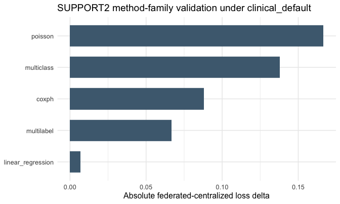

```r
if (requireNamespace("ggplot2", quietly = TRUE)) {
  plot_data <- results
  plot_data$label <- sub("^pytorch_", "", plot_data$method)
  plot_data$abs_delta <- abs(plot_data$delta_loss)
  ggplot2::ggplot(plot_data, ggplot2::aes(
    x = stats::reorder(label, abs_delta),
    y = abs_delta
  )) +
    ggplot2::geom_col(width = 0.68, fill = "#4D6A7F") +
    ggplot2::coord_flip() +
    ggplot2::labs(
      x = NULL,
      y = "Absolute federated-centralized loss delta",
      title = "SUPPORT2 method-family validation under clinical_default"
    ) +
    ggplot2::theme_minimal(base_size = 12)
}
```

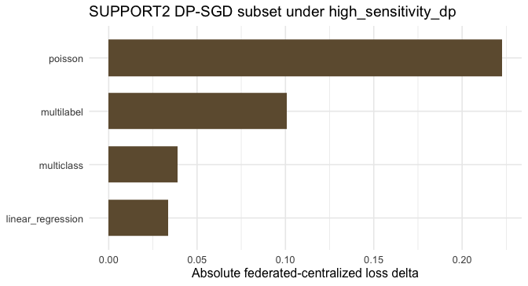

```r
if (requireNamespace("ggplot2", quietly = TRUE)) {
  plot_data <- dp_results
  plot_data$label <- sub("^pytorch_", "", plot_data$method)
  plot_data$abs_delta <- abs(plot_data$delta_loss)
  ggplot2::ggplot(plot_data, ggplot2::aes(
    x = stats::reorder(label, abs_delta),
    y = abs_delta
  )) +
    ggplot2::geom_col(width = 0.68, fill = "#6F5B3E") +
    ggplot2::coord_flip() +
    ggplot2::labs(
      x = NULL,
      y = "Absolute federated-centralized loss delta",
      title = "SUPPORT2 DP-SGD subset under high_sensitivity_dp"
    ) +
    ggplot2::theme_minimal(base_size = 12)
}
```

The canonical run can be regenerated from a local three-Opal demonstration deployment with:

```r
Sys.setenv(
  DSFLOWER_SUPPORT2_LIMIT = "3000",
  DSFLOWER_FAMILY_PRIVACY_PROFILE = "clinical_default"
)
source(system.file(
  "demos", "benchmark_method_families.R",
  package = "dsFlowerClient"
))
```

```r
Sys.setenv(
  DSFLOWER_SUPPORT2_LIMIT = "3000",
  DSFLOWER_FAMILY_PRIVACY_PROFILE = "high_sensitivity_dp",
  DSFLOWER_FAMILY_MODELS =
    "pytorch_linear_regression,pytorch_poisson,pytorch_multiclass,pytorch_multilabel",
  DSFLOWER_FAMILY_MULTICLASS_ROUNDS = "6",
  DSFLOWER_FAMILY_DP_EPSILON = "8",
  DSFLOWER_FAMILY_DP_DELTA = "1e-5",
  DSFLOWER_FAMILY_DP_CLIP = "1",
  DSFLOWER_FAMILY_EVIDENCE_FILE =
    "inst/extdata/dsflower_method_family_dp_results.json"
)
source(system.file(
  "demos", "benchmark_method_families.R",
  package = "dsFlowerClient"
))
```